# Olympic Athletics

Cheryl Allen-Munley

4/30/2022

```r
library(rlang)
library(curl)
library (dplyr)
```

```r
library (ggplot2)
library(httr)
library(jsonlite)
library(lubridate)
library(readxl)
library(rvest)
library(tidytext)
library(tidyverse)
library (topicmodels)
```

My first task was to extract the Kaggle data and filter for my sport:Athlectics (Track & Field). The Kaggle table provides important information about the contestants and the event, but with one glaring ommission: Kaggle does not include the performance (time, height, score, etc.) of the actual event. For this reason, additional data had to be scraped from Wikipedia.

```r
kaggle_athletics <- read_excel("athlete_events.xlsx")%>%
filter(Sport == "Athletics")
head(kaggle_athletics)
```

```
## # A tibble: 6 × 15
##      ID Name      Sex   Age   Height Weight Team  NOC   Games  Year Season City
##   <dbl> <chr>     <chr> <chr> <chr>  <chr>  <chr> <chr> <chr> <dbl> <chr>  <chr>
## 1     8 "Corneli… F     18    168    NA     Neth… NED   1932…  1932 Summer Los …
## 2     8 "Corneli… F     18    168    NA     Neth… NED   1932…  1932 Summer Los …
## 3    18 "Timo An… M     31    189    130    Finl… FIN   2000…  2000 Summer Sydn…
## 4    31 "Evald r… M     24    174    70     Esto… EST   1936…  1936 Summer Berl…
## 5    32 "Olav Au… M     23    NA     NA     Norw… NOR   1912…  1912 Summer Stoc…
## 6    34 "Jamale … M     30    187    76     Fran… FRA   2012…  2012 Summer Lond…
## # … with 3 more variables: Sport <chr>, Event <chr>, Medal <chr>
```

Wikipedia has separate sites for each Olympic year with separate tables, which varied by year, for male and female performance. To join the Wikipedia data with Kaggle, I first had to scrape it from the Wikipedia site, rename the columns, clean the event fields in both the Kaggle and Wikipedia files, so that they would match.

```r
olympic_join = function(func_year, func_url,table_num,gender) {
#Get the Kaggle files and remove the prefixes "Athletics Men's" and Athletics Women's from the event field.
  kaggle_athletics_year <- kaggle_athletics%>%
  filter(Sex == gender, Year == func_year) %>% arrange(Year) %>%
  mutate(Event = trimws(str_replace_all(Event, "Athletics Men's", ""))) %>%
  mutate(Event = trimws(str_replace_all(Event, "Athletics Women's", "")))

#Scrape the data from Wikipedia given the functional year.
  athletics_year <- func_url%>%
  read_html() %>%
  html_nodes("table")%>%
  html_table(fill=TRUE)

#rename columns to guaranty first column is always "Event" even if column title changes for each Olympic year, and each of the pairs of name and performance for each medal is titled "Name" and "Time."
wiki_year <- athletics_year[[table_num]]
colnames(wiki_year)[1] <- "Event"
colnames(wiki_year)[2] <- "Name"
colnames(wiki_year)[3] <- "Time"
colnames(wiki_year)[4] <- "Name"
colnames(wiki_year)[5] <- "Time"
colnames(wiki_year)[6] <- "Name"
colnames(wiki_year)[7] <- "Time"

#Clean field on Wiki, removing "details". Join with Kaggle for gold medalists (rank =1).
wiki_year_g<- wiki_year %>%
  select (1:3)%>%
    mutate(Event = str_replace_all(Event,"details",""))
wiki_year_g$Rank <- "1"

#Kaggle athletic data and wikipedia data joined for year Gold.
kaggle_athletics_year_g <- kaggle_athletics_year%>%
  filter(Year == func_year, Medal == "Gold", Event == "Marathon" | Event == "100 metres" | Event == "800 metres")
final_year_g <- left_join(kaggle_athletics_year_g,wiki_year_g,by = "Event")

#Repeat year for Silver
wiki_year_s<- wiki_year %>%
  select (1, 4:5)%>%
    mutate(Event = str_replace_all(Event,"details",""))
wiki_year_s$Rank <- "2"

#Kaggle athletic data and wikipedia data joined for year and silver medalists.
kaggle_athletics_year_s <- kaggle_athletics%>%
  filter(Year == func_year, Medal == "Silver", Event == "Marathon" | Event == "100 metres" | Event == "800 metres")
final_year_s <- left_join(kaggle_athletics_year_s,wiki_year_s,by = "Event")

#Do the same for Bronze
wiki_year_b<- wiki_year %>%
  select (1, 6:7)%>%
    mutate(Event = str_replace_all(Event,"details",""))
wiki_year_b$Rank <- "3"

#Kaggle athletic data and wikipedia data joined for year and bronze medalists.
kaggle_athletics_year_b <- kaggle_athletics%>%
  filter(Year == func_year, Medal == "Bronze", Event == "Marathon" | Event == "100 metres" | Event == "800 metres")
final_year_b <- left_join(kaggle_athletics_year_b,wiki_year_b,by = "Event")

#Consolidate gold, silver and bronze for year
final_year <- final_year_g %>%
   rbind.data.frame(final_year_s) %>%
   rbind.data.frame(final_year_b)
#   select(1:7, 10:13, 15, 16, 19)
final_year
}
```

Begin calling the function olympic_join for each of the Olympics by year, starting in 2016.

```r
result_m <- olympic_join("2016","https://en.wikipedia.org/wiki/Athletics_at_the_2016_Summer_Olympics", 6, "M")
result_w <- olympic_join("2016","https://en.wikipedia.org/wiki/Athletics_at_the_2016_Summer_Olympics", 7, "F")
```

The rows of each subsequent years are appended to 2016, separated by sex.

```r
result_new <- olympic_join("2012", "https://en.wikipedia.org/wiki/Athletics_at_the_2012_Summer_Olympics",7, "M")
result_m <- result_m %>%
rbind.data.frame(result_new)
result_new <- olympic_join("2012", "https://en.wikipedia.org/wiki/Athletics_at_the_2012_Summer_Olympics",8, "F")
result_w <- result_w %>%
rbind.data.frame(result_new)
```

```r
result_new <- olympic_join("2008", "https://en.wikipedia.org/wiki/Athletics_at_the_2008_Summer_Olympics",4, "M")
result_m <- result_m %>%
rbind.data.frame(result_new)
result_new <- olympic_join("2008", "https://en.wikipedia.org/wiki/Athletics_at_the_2012_Summer_Olympics",5, "F")
result_w <- result_w %>%
rbind.data.frame(result_new)
```

```r
result_new <- olympic_join("2004", "https://en.wikipedia.org/wiki/Athletics_at_the_2004_Summer_Olympics",3, "M")
result_m <- result_m %>%
rbind.data.frame(result_new)
result_new <- olympic_join("2004", "https://en.wikipedia.org/wiki/Athletics_at_the_2004_Summer_Olympics",4, "F")
result_w <- result_w %>%
rbind.data.frame(result_new)
```

```r
result_new <- olympic_join("2000", "https://en.wikipedia.org/wiki/Athletics_at_the_2000_Summer_Olympics",3, "M")
result_m <- result_m %>%
rbind.data.frame(result_new)
result_new <- olympic_join("2000", "https://en.wikipedia.org/wiki/Athletics_at_the_2000_Summer_Olympics",4, "F")
result_w <- result_w %>%
rbind.data.frame(result_new)
```

```r
result_new <- olympic_join("1996", "https://en.wikipedia.org/wiki/Athletics_at_the_1996_Summer_Olympics",2, "M")
result_m <- result_m %>%
rbind.data.frame(result_new)
result_new <- olympic_join("1996", "https://en.wikipedia.org/wiki/Athletics_at_the_1996_Summer_Olympics",3, "F")
result_w <- result_w %>%
rbind.data.frame(result_new)
```

```r
result_new <- olympic_join("1992", "https://en.wikipedia.org/wiki/Athletics_at_the_1992_Summer_Olympics",2, "M")
result_m <- result_m %>%
rbind.data.frame(result_new)
result_new <- olympic_join("1992", "https://en.wikipedia.org/wiki/Athletics_at_the_1992_Summer_Olympics",3, "F")
result_w <- result_w %>%
rbind.data.frame(result_new)
result_w
```

```
## # A tibble: 20 × 18
##        ID Name.x  Sex   Age   Height Weight Team  NOC   Games  Year Season City
##     <dbl> <chr>   <chr> <chr> <chr>  <chr>  <chr> <chr> <chr> <dbl> <chr>  <chr>
##  1 108532 Mokgad… F     25    178    70     Sout… RSA   2016…  2016 Summer Rio …
##  2 116424 Jemima… F     31    160    45     Kenya KEN   2016…  2016 Summer Rio …
##  3 119903 Elaine… F     24    167    57     Jama… JAM   2016…  2016 Summer Rio …
##  4  36870 Shelly… F     25    160    57     Jama… JAM   2012…  2012 Summer Lond…
##  5  39396 Erba T… F     24    165    48     Ethi… ETH   2012…  2012 Summer Lond…
##  6 106272 Mariya… F     26    172    60     Russ… RUS   2012…  2012 Summer Lond…
##  7  28766 Consta… F     38    160    48     Roma… ROU   2008…  2008 Summer Beij…
##  8  36870 Shelly… F     21    160    57     Jama… JAM   2008…  2008 Summer Beij…
##  9  54227 Pamela… F     18    175    60     Kenya KEN   2008…  2008 Summer Beij…
## 10  49498 Kelly … F     34    163    55     Grea… GBR   2004…  2004 Summer Athi…
## 11  85373 Yuliya… F     25    176    62     Bela… BLR   2004…  2004 Summer Athi…
## 12  86753 Mizuki… F     26    150    40     Japan JPN   2004…  2004 Summer Athi…
## 13  83769 Maria … F     27    165    63     Moza… MOZ   2000…  2000 Summer Sydn…
## 14 117930 Naoko … F     28    161    52     Japan JPN   2000…  2000 Summer Sydn…
## 15  27940 Yoland… F     29    160    55     Unit… USA   1996…  1996 Summer Atla…
## 16  76272 Svetla… F     28    168    50     Russ… RUS   1996…  1996 Summer Atla…
## 17 101226 Fatuma… F     22    160    49     Ethi… ETH   1996…  1996 Summer Atla…
## 18  27940 Yoland… F     25    160    55     Unit… USA   1992…  1992 Summer Barc…
## 19 124735 Ellen … F     26    172    57     Neth… NED   1992…  1992 Summer Barc…
## 20 132794 Valent… F     28    155    50     Unif… EUN   1992…  1992 Summer Barc…
## # … with 6 more variables: Sport <chr>, Event <chr>, Medal <chr>, Name.y <chr>,
## #   Time <chr>, Rank <chr>
```

```r
result_new <- olympic_join("1988", "https://en.wikipedia.org/wiki/Athletics_at_the_1988_Summer_Olympics",2, "M")
result_m <- result_m %>%
rbind.data.frame(result_new)
result_new <- olympic_join("1988", "https://en.wikipedia.org/wiki/Athletics_at_the_1988_Summer_Olympics",3, "F")
result_w <- result_w %>%
rbind.data.frame(result_new)
```

```r
result_new <- olympic_join("1984", "https://en.wikipedia.org/wiki/Athletics_at_the_1984_Summer_Olympics",3, "M")
result_m <- result_m %>%
rbind.data.frame(result_new)
result_new <- olympic_join("1984", "https://en.wikipedia.org/wiki/Athletics_at_the_1984_Summer_Olympics",4, "F")
result_w <- result_w %>%
rbind.data.frame(result_new)
```

```r
result_new <- olympic_join("1980", "https://en.wikipedia.org/wiki/Athletics_at_the_1980_Summer_Olympics",4, "M")
result_m <- result_m %>%
rbind.data.frame(result_new)
result_new <- olympic_join("1980", "https://en.wikipedia.org/wiki/Athletics_at_the_1980_Summer_Olympics",5, "F")
result_w <- result_w %>%
rbind.data.frame(result_new)
```

```r
result_new <- olympic_join("1976", "https://en.wikipedia.org/wiki/Athletics_at_the_1976_Summer_Olympics",1, "M")
result_m <- result_m %>%
rbind.data.frame(result_new)
result_new <- olympic_join("1976", "https://en.wikipedia.org/wiki/Athletics_at_the_1976_Summer_Olympics",2, "F")
result_w <- result_w %>%
rbind.data.frame(result_new)
```

```r
result_new <- olympic_join("1972", "https://en.wikipedia.org/wiki/Athletics_at_the_1972_Summer_Olympics",1, "M")
result_m <- result_m %>%
rbind.data.frame(result_new)
result_new <- olympic_join("1972", "https://en.wikipedia.org/wiki/Athletics_at_the_1972_Summer_Olympics",2, "F")
result_w <- result_w %>%
rbind.data.frame(result_new)
```

```r
result_new <- olympic_join("1968", "https://en.wikipedia.org/wiki/Athletics_at_the_1968_Summer_Olympics",2, "M")
result_m <- result_m %>%
rbind.data.frame(result_new)
result_new <- olympic_join("1968", "https://en.wikipedia.org/wiki/Athletics_at_the_1968_Summer_Olympics",3, "F")
result_w <- result_w %>%
rbind.data.frame(result_new)
```

```r
result_new <- olympic_join("1964", "https://en.wikipedia.org/wiki/Athletics_at_the_1964_Summer_Olympics",1, "M")
result_m <- result_m %>%
rbind.data.frame(result_new)
result_new <- olympic_join("1964", "https://en.wikipedia.org/wiki/Athletics_at_the_1964_Summer_Olympics",2, "F")
result_w <- result_w %>%
rbind.data.frame(result_new)
```

```r
result_new <- olympic_join("1960", "https://en.wikipedia.org/wiki/Athletics_at_the_1960_Summer_Olympics",3, "M")
result_m <- result_m %>%
rbind.data.frame(result_new)
result_new <- olympic_join("1960", "https://en.wikipedia.org/wiki/Athletics_at_the_1960_Summer_Olympics",4, "F")
result_w <- result_w %>%
rbind.data.frame(result_new)
```

```r
result_new <- olympic_join("1956", "https://en.wikipedia.org/wiki/Athletics_at_the_1956_Summer_Olympics",2, "M")
result_m <- result_m %>%
rbind.data.frame(result_new)
result_new <- olympic_join("1956", "https://en.wikipedia.org/wiki/Athletics_at_the_1956_Summer_Olympics",3, "F")
result_w <- result_w %>%
rbind.data.frame(result_new)
```

```r
result_new <- olympic_join("1952", "https://en.wikipedia.org/wiki/Athletics_at_the_1952_Summer_Olympics",2, "M")
result_m <- result_m %>%
rbind.data.frame(result_new)
result_new <- olympic_join("1952", "https://en.wikipedia.org/wiki/Athletics_at_the_1952_Summer_Olympics",3, "F")
result_w <- result_w %>%
rbind.data.frame(result_new)
```

```r
result_new <- olympic_join("1948", "https://en.wikipedia.org/wiki/Athletics_at_the_1948_Summer_Olympics",3, "M")
result_m <- result_m %>%
rbind.data.frame(result_new)
result_new <- olympic_join("1948", "https://en.wikipedia.org/wiki/Athletics_at_the_1948_Summer_Olympics",4, "F")
result_w <- result_w %>%
rbind.data.frame(result_new)
```

```r
result_new <- olympic_join("1936", "https://en.wikipedia.org/wiki/Athletics_at_the_1936_Summer_Olympics",3, "M")
result_m <- result_m %>%
rbind.data.frame(result_new)
result_m
```

```
## # A tibble: 57 × 18
##        ID Name.x  Sex   Age   Height Weight Team  NOC   Games  Year Season City
##     <dbl> <chr>   <chr> <chr> <chr>  <chr>  <chr> <chr> <chr> <dbl> <chr>  <chr>
##  1  13029 "Usain… M     29    196    95     Jama… JAM   2016…  2016 Summer Rio …
##  2  60589 "Eliud… M     31    167    57     Kenya KEN   2016…  2016 Summer Rio …
##  3 103274 "David… M     27    190    76     Kenya KEN   2016…  2016 Summer Rio …
##  4  13029 "Usain… M     25    196    95     Jama… JAM   2012…  2012 Summer Lond…
##  5  60618 "Steph… M     23    172    56     Ugan… UGA   2012…  2012 Summer Lond…
##  6 103274 "David… M     23    190    76     Kenya KEN   2012…  2012 Summer Lond…
##  7  13029 "Usain… M     21    196    95     Jama… JAM   2008…  2008 Summer Beij…
##  8  16430 "Wilfr… M     28    172    60     Kenya KEN   2008…  2008 Summer Beij…
##  9 128675 "Samue… M     21    163    51     Kenya KEN   2008…  2008 Summer Beij…
## 10   7219 "Stefa… M     33    176    62     Italy ITA   2004…  2004 Summer Athi…
## # … with 47 more rows, and 6 more variables: Sport <chr>, Event <chr>,
## #   Medal <chr>, Name.y <chr>, Time <chr>, Rank <chr>
```

```r
result_new <- olympic_join("1936", "https://en.wikipedia.org/wiki/Athletics_at_the_1936_Summer_Olympics",4, "F")
result_w <- result_w %>%
rbind.data.frame(result_new)
result_w
```

```
## # A tibble: 42 × 18
##        ID Name.x  Sex   Age   Height Weight Team  NOC   Games  Year Season City
##     <dbl> <chr>   <chr> <chr> <chr>  <chr>  <chr> <chr> <chr> <dbl> <chr>  <chr>
##  1 108532 Mokgad… F     25    178    70     Sout… RSA   2016…  2016 Summer Rio …
##  2 116424 Jemima… F     31    160    45     Kenya KEN   2016…  2016 Summer Rio …
##  3 119903 Elaine… F     24    167    57     Jama… JAM   2016…  2016 Summer Rio …
##  4  36870 Shelly… F     25    160    57     Jama… JAM   2012…  2012 Summer Lond…
##  5  39396 Erba T… F     24    165    48     Ethi… ETH   2012…  2012 Summer Lond…
##  6 106272 Mariya… F     26    172    60     Russ… RUS   2012…  2012 Summer Lond…
##  7  28766 Consta… F     38    160    48     Roma… ROU   2008…  2008 Summer Beij…
##  8  36870 Shelly… F     21    160    57     Jama… JAM   2008…  2008 Summer Beij…
##  9  54227 Pamela… F     18    175    60     Kenya KEN   2008…  2008 Summer Beij…
## 10  49498 Kelly … F     34    163    55     Grea… GBR   2004…  2004 Summer Athi…
## # … with 32 more rows, and 6 more variables: Sport <chr>, Event <chr>,
## #   Medal <chr>, Name.y <chr>, Time <chr>, Rank <chr>
```

Select columns from women’s and men’s data frames, eliminating duplicates that were created in the join.

```r
athletics_m_final <- result_m%>%
select(2:7,10,12:14,17,18)
athletics_m_final
```

```
## # A tibble: 57 × 12
##    Name.x    Sex   Age   Height Weight Team   Year City  Sport Event Time  Rank
##    <chr>     <chr> <chr> <chr>  <chr>  <chr> <dbl> <chr> <chr> <chr> <chr> <chr>
##  1 "Usain S… M     29    196    95     Jama…  2016 Rio … Athl… 100 … 9.81  1
##  2 "Eliud K… M     31    167    57     Kenya  2016 Rio … Athl… Mara… 2:08… 1
##  3 "David L… M     27    190    76     Kenya  2016 Rio … Athl… 800 … 1:42… 1
##  4 "Usain S… M     25    196    95     Jama…  2012 Lond… Athl… 100 … 9.63… 1
##  5 "Stephen… M     23    172    56     Ugan…  2012 Lond… Athl… Mara… 2:08… 1
##  6 "David L… M     23    190    76     Kenya  2012 Lond… Athl… 800 … 1:40… 1
##  7 "Usain S… M     21    196    95     Jama…  2008 Beij… Athl… 100 … 9.69… 1
##  8 "Wilfred… M     28    172    60     Kenya  2008 Beij… Athl… 800 … 1:44… 1
##  9 "Samuel … M     21    163    51     Kenya  2008 Beij… Athl… Mara… 2:06… 1
## 10 "Stefano… M     33    176    62     Italy  2004 Athi… Athl… Mara… <NA>  <NA>
## # … with 47 more rows
```

```r
athletics_w_final <- result_w%>%
select(2:7,10,12:14,17,18)
athletics_w_final
```

```
## # A tibble: 42 × 12
##    Name.x    Sex   Age   Height Weight Team   Year City  Sport Event Time  Rank
##    <chr>     <chr> <chr> <chr>  <chr>  <chr> <dbl> <chr> <chr> <chr> <chr> <chr>
##  1 Mokgadi … F     25    178    70     Sout…  2016 Rio … Athl… 800 … "1:5… 1
##  2 Jemima J… F     31    160    45     Kenya  2016 Rio … Athl… Mara… "2:2… 1
##  3 Elaine T… F     24    167    57     Jama…  2016 Rio … Athl… 100 … "10.… 1
##  4 Shelly-A… F     25    160    57     Jama…  2012 Lond… Athl… 100 … "10.… 1
##  5 Erba Tik… F     24    165    48     Ethi…  2012 Lond… Athl… Mara… "2:2… 1
##  6 Mariya S… F     26    172    60     Russ…  2012 Lond… Athl… 800 …  <NA> <NA>
##  7 Constant… F     38    160    48     Roma…  2008 Beij… Athl… Mara… ""    1
##  8 Shelly-A… F     21    160    57     Jama…  2008 Beij… Athl… 100 …  <NA> <NA>
##  9 Pamela J… F     18    175    60     Kenya  2008 Beij… Athl… 800 …  <NA> <NA>
## 10 Kelly Ho… F     34    163    55     Grea…  2004 Athi… Athl… 800 …  <NA> <NA>
## # … with 32 more rows
```

```r
athletics_m_final <-athletics_m_final %>% na.omit() %>%
    mutate(Time = str_extract(Time,"[0-9':''.']+"))

athletics_m_hms <- athletics_m_final %>%
  filter(str_detect(athletics_m_final$Time,":"))
  athletics_m_hms$Time <- period_to_seconds(hms(athletics_m_hms$Time))

athletics_m_final <- athletics_m_final %>%
  filter(str_detect(athletics_m_final$Time,":") == "FALSE") %>%
rbind(athletics_m_hms)%>%
arrange(Event)
head(athletics_m_final)
```

```
## # A tibble: 6 × 12
##   Name.x     Sex   Age   Height Weight Team   Year City  Sport Event Time  Rank
##   <chr>      <chr> <chr> <chr>  <chr>  <chr> <dbl> <chr> <chr> <chr> <chr> <chr>
## 1 Usain St.… M     29    196    95     Jama…  2016 Rio … Athl… 100 … 9.81  1
## 2 Usain St.… M     25    196    95     Jama…  2012 Lond… Athl… 100 … 9.63  1
## 3 Usain St.… M     21    196    95     Jama…  2008 Beij… Athl… 100 … 9.69  1
## 4 Justin Al… M     22    186    80     Unit…  2004 Athi… Athl… 100 … 9.85  1
## 5 Maurice G… M     26    176    80     Unit…  2000 Sydn… Athl… 100 … 9.87  1
## 6 Donovan B… M     28    183    82     Cana…  1996 Atla… Athl… 100 … 9.84  1
```

```r
athletics_w_final <-athletics_w_final %>% na.omit() %>%
    mutate(Time = str_extract(Time,"[0-9':''.']+"))

athletics_w_hms <- athletics_w_final %>%
  filter(str_detect(athletics_w_final$Time,":"))
  athletics_w_hms$Time <- period_to_seconds(hms(athletics_w_hms$Time))

athletics_w_final <- athletics_w_final %>%
  filter(str_detect(athletics_w_final$Time,":") == "FALSE") %>%
rbind(athletics_w_hms )%>%
 arrange(Event)
 head(athletics_w_final)
```

```
## # A tibble: 6 × 12
##   Name.x     Sex   Age   Height Weight Team   Year City  Sport Event Time  Rank
##   <chr>      <chr> <chr> <chr>  <chr>  <chr> <dbl> <chr> <chr> <chr> <chr> <chr>
## 1 Elaine Th… F     24    167    57     Jama…  2016 Rio … Athl… 100 … 10.71 1
## 2 Shelly-An… F     25    160    57     Jama…  2012 Lond… Athl… 100 … 10.75 1
## 3 Yolanda G… F     29    160    55     Unit…  1996 Atla… Athl… 100 … 10.94 1
## 4 Yolanda G… F     25    160    55     Unit…  1992 Barc… Athl… 100 … 10.82 1
## 5 Delorez F… F     28    170    57     Unit…  1988 Seoul Athl… 100 … 10.54 1
## 6 Evelyn As… F     27    165    52     Unit…  1984 Los … Athl… 100 … 10.97 1
```

```r
athletics_m_final$BMI <- as.numeric(athletics_m_final$Weight)/((as.numeric(athletics_m_final$Height)/100)**2)
athletics_w_final$BMI <-
 as.numeric(athletics_w_final$Weight)/((as.numeric(athletics_w_final$Height)/100)**2)
```

```r
marathon_m <- athletics_m_final %>%
  filter(Event == "Marathon")
marathon_lm_m = lm(as.numeric(marathon_m$Time)~marathon_m$BMI)
  summary(marathon_lm_m)
```

```
##
## Call:
## lm(formula = as.numeric(marathon_m$Time) ~ marathon_m$BMI)
##
## Residuals:
##    Min     1Q Median     3Q    Max
## -480.8 -358.2 -136.1  284.9 1169.8
##
## Coefficients:
##                Estimate Std. Error t value Pr(>|t|)
## (Intercept)     6813.85    2164.09   3.149  0.00621 **
## marathon_m$BMI    65.59     109.41   0.599  0.55728
## ---
## Signif. codes:  0 '***' 0.001 '**' 0.01 '*' 0.05 '.' 0.1 ' ' 1
##
## Residual standard error: 490.5 on 16 degrees of freedom
## Multiple R-squared:  0.02196,    Adjusted R-squared:  -0.03916
## F-statistic: 0.3593 on 1 and 16 DF,  p-value: 0.5573
```

```r
marathon_w <- athletics_w_final %>%
  filter(Event == "Marathon")
marathon_lm_w = lm(as.numeric(marathon_w$Time)~marathon_w$BMI)
  summary(marathon_lm_w)
```

```
##
## Call:
## lm(formula = as.numeric(marathon_w$Time) ~ marathon_w$BMI)
##
## Residuals:
##        1        2        3        4        5        6        7
##   45.958  -16.822 -276.171   -4.299  208.549   67.625  -24.841
##
## Coefficients:
##                Estimate Std. Error t value Pr(>|t|)
## (Intercept)     6671.41    1012.54   6.589  0.00121 **
## marathon_w$BMI   109.60      53.54   2.047  0.09600 .
## ---
## Signif. codes:  0 '***' 0.001 '**' 0.01 '*' 0.05 '.' 0.1 ' ' 1
##
## Residual standard error: 159.6 on 5 degrees of freedom
## Multiple R-squared:  0.456,  Adjusted R-squared:  0.3471
## F-statistic:  4.19 on 1 and 5 DF,  p-value: 0.096
```

```r
hundred_m <- athletics_m_final %>%
  filter(Event == "100 metres")
hundred_lm_m = lm(as.numeric(hundred_m$Time)~hundred_m$BMI)
  summary(hundred_lm_m)
```

```
##
## Call:
## lm(formula = as.numeric(hundred_m$Time) ~ hundred_m$BMI)
##
## Residuals:
##      Min       1Q   Median       3Q      Max
## -0.33756 -0.15240 -0.00886  0.13275  0.35931
##
## Coefficients:
##               Estimate Std. Error t value Pr(>|t|)
## (Intercept)   11.96671    0.73988  16.174 9.31e-12 ***
## hundred_m$BMI -0.08084    0.03089  -2.617    0.018 *
## ---
## Signif. codes:  0 '***' 0.001 '**' 0.01 '*' 0.05 '.' 0.1 ' ' 1
##
## Residual standard error: 0.2086 on 17 degrees of freedom
## Multiple R-squared:  0.2871, Adjusted R-squared:  0.2452
## F-statistic: 6.847 on 1 and 17 DF,  p-value: 0.01805
```

```r
hundred_w <- athletics_w_final %>%
  filter(Event == "100 metres")
hundred_lm_w = lm(as.numeric(hundred_w$Time)~hundred_w$BMI)
  summary(hundred_lm_w)
```

```
##
## Call:
## lm(formula = as.numeric(hundred_w$Time) ~ hundred_w$BMI)
##
## Residuals:
##      Min       1Q   Median       3Q      Max
## -0.55820 -0.21539 -0.06017  0.30644  0.78870
##
## Coefficients:
##               Estimate Std. Error t value Pr(>|t|)
## (Intercept)   10.79371    1.30320   8.282 9.12e-07 ***
## hundred_w$BMI  0.01544    0.06271   0.246    0.809
## ---
## Signif. codes:  0 '***' 0.001 '**' 0.01 '*' 0.05 '.' 0.1 ' ' 1
##
## Residual standard error: 0.3704 on 14 degrees of freedom
## Multiple R-squared:  0.004311,   Adjusted R-squared:  -0.06681
## F-statistic: 0.06062 on 1 and 14 DF,  p-value: 0.8091
```

```r
eight_hundred_m <- athletics_m_final %>%
  filter(Event == "800 metres")
eight_hundred_lm_m = lm(as.numeric(eight_hundred_m$Time)~eight_hundred_m$BMI)
  summary(eight_hundred_lm_m)
```

```
##
## Call:
## lm(formula = as.numeric(eight_hundred_m$Time) ~ eight_hundred_m$BMI)
##
## Residuals:
##     Min      1Q  Median      3Q     Max
## -224.40 -101.87  -19.36   71.54  414.27
##
## Coefficients:
##                     Estimate Std. Error t value Pr(>|t|)
## (Intercept)          6064.99     547.33  11.081 6.47e-09 ***
## eight_hundred_m$BMI    11.89      25.20   0.472    0.643
## ---
## Signif. codes:  0 '***' 0.001 '**' 0.01 '*' 0.05 '.' 0.1 ' ' 1
##
## Residual standard error: 163.8 on 16 degrees of freedom
## Multiple R-squared:  0.01373,    Adjusted R-squared:  -0.04791
## F-statistic: 0.2227 on 1 and 16 DF,  p-value: 0.6433
```

```r
eight_hundred_w <- athletics_w_final %>%
  filter(Event == "800 metres")
eight_hundred_lm_w = lm(as.numeric(eight_hundred_w$Time)~eight_hundred_w$BMI)
  summary(eight_hundred_lm_w)
```

```
##
## Call:
## lm(formula = as.numeric(eight_hundred_w$Time) ~ eight_hundred_w$BMI)
##
## Residuals:
##     Min      1Q  Median      3Q     Max
## -255.54 -120.65  -45.21   97.93  374.22
##
## Coefficients:
##                     Estimate Std. Error t value Pr(>|t|)
## (Intercept)         6912.428    580.984  11.898 3.17e-07 ***
## eight_hundred_w$BMI    7.934     28.403   0.279    0.786
## ---
## Signif. codes:  0 '***' 0.001 '**' 0.01 '*' 0.05 '.' 0.1 ' ' 1
##
## Residual standard error: 189.4 on 10 degrees of freedom
## Multiple R-squared:  0.007743,   Adjusted R-squared:  -0.09148
## F-statistic: 0.07803 on 1 and 10 DF,  p-value: 0.7857
```

Interestingly, the second order component of weight in the formula for BMI results in an improvement in performance (seconds decline) as BMI increases, up until approximately BMI = 25. Above that value, performance decreases. Perhaps, a certain amount of muscle mass is optimum to achieve the maximum amount of human speed, but above that BMI, it takes too much force to accelerate the mass.

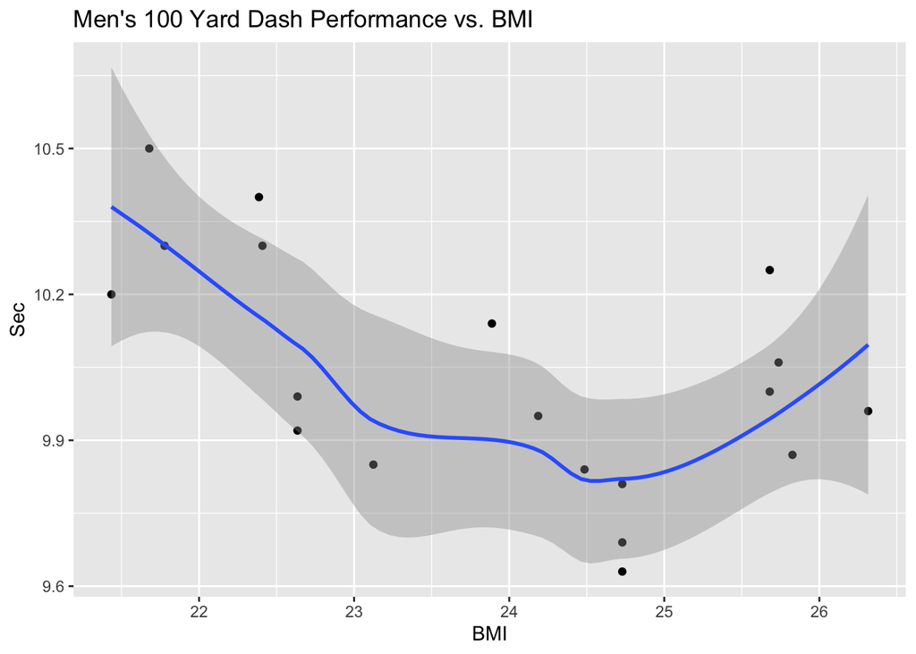

```r
 hundred_m_plot<- ggplot(data = hundred_m, aes(BMI, as.numeric(Time))) +xlab("BMI") + ylab("Sec") +
  geom_point() +
  ggtitle("Men's 100 Yard Dash Performance vs. BMI") +
  geom_smooth()
hundred_m_plot
```

The comparison of women’s BMI to 100 yard dash performance does not replicate this trend, as was anticipated by the high p-value for the estimate and low r_square.

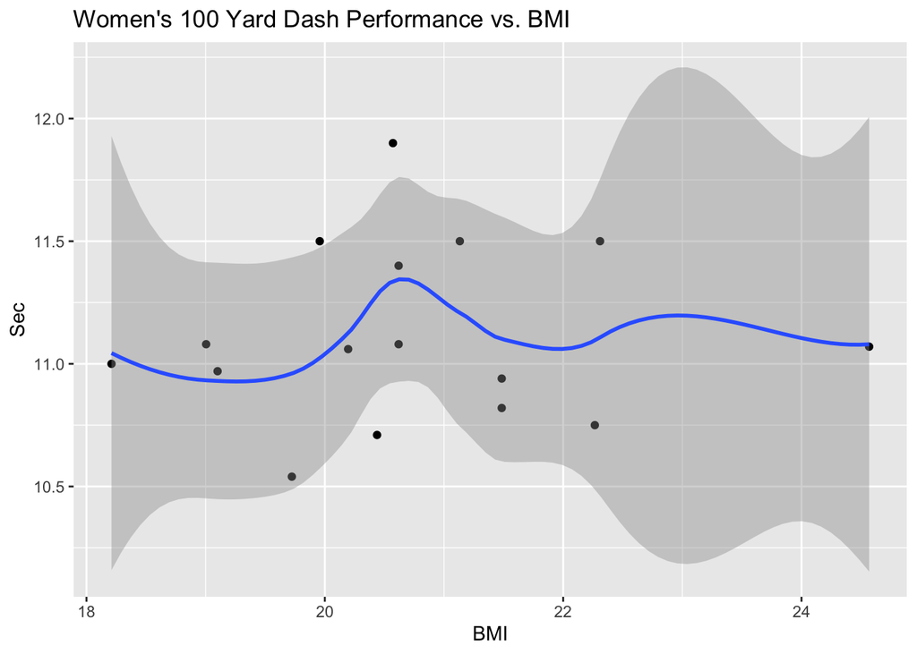

```r
 hundred_w_plot<- ggplot(data = hundred_w, aes(BMI, as.numeric(Time))) +xlab("BMI") + ylab("Sec") +
  geom_point() +
  ggtitle("Women's 100 Yard Dash Performance vs. BMI") +
  geom_smooth()
hundred_w_plot
```

Select columns from Athletics tables for plotting women vs. men’s performance over time.

```r
Olympic_m<- athletics_m_final
Olympic_m$Sex = "M"

Olympic_w<- athletics_w_final
Olympic_w$Sex = "F"

Olympics_Athletics <- Olympic_m %>%
  rbind(Olympic_w) %>%
  select (9,10,7,2,11,12)
  #filter(Rank == "1" )
Olympics_Athletics
```

```
## # A tibble: 90 × 6
##    Sport     Event       Year Sex   Time  Rank
##    <chr>     <chr>      <dbl> <chr> <chr> <chr>
##  1 Athletics 100 metres  2016 M     9.81  1
##  2 Athletics 100 metres  2012 M     9.63  1
##  3 Athletics 100 metres  2008 M     9.69  1
##  4 Athletics 100 metres  2004 M     9.85  1
##  5 Athletics 100 metres  2000 M     9.87  1
##  6 Athletics 100 metres  1996 M     9.84  1
##  7 Athletics 100 metres  1992 M     9.96  1
##  8 Athletics 100 metres  1988 M     9.92  1
##  9 Athletics 100 metres  1984 M     9.99  1
## 10 Athletics 100 metres  1980 M     10.25 1
## # … with 80 more rows
```

Women were not allowed to run the Marathon until 1984. An investigation of the sharp increase in time for the women’s Marathon in 1992 was due to a course that finished up a steep incline, sapping their strength at the end of the event.

```r
marathon <- Olympics_Athletics %>%
  filter(Event == "Marathon")
  marathon$Hours = as.numeric(marathon$Time)/3600
marathon
```

```
## # A tibble: 25 × 7
##    Sport     Event     Year Sex   Time  Rank  Hours
##    <chr>     <chr>    <dbl> <chr> <chr> <chr> <dbl>
##  1 Athletics Marathon  2016 M     7724  1      2.15
##  2 Athletics Marathon  2012 M     7681  1      2.13
##  3 Athletics Marathon  2008 M     7592  1      2.11
##  4 Athletics Marathon  2000 M     7811  1      2.17
##  5 Athletics Marathon  1996 M     7956  1      2.21
##  6 Athletics Marathon  1992 M     8003  1      2.22
##  7 Athletics Marathon  1988 M     7832  1      2.18
##  8 Athletics Marathon  1984 M     7761  1      2.16
##  9 Athletics Marathon  1980 M     7863  1      2.18
## 10 Athletics Marathon  1976 M     7795  1      2.17
## # … with 15 more rows
```

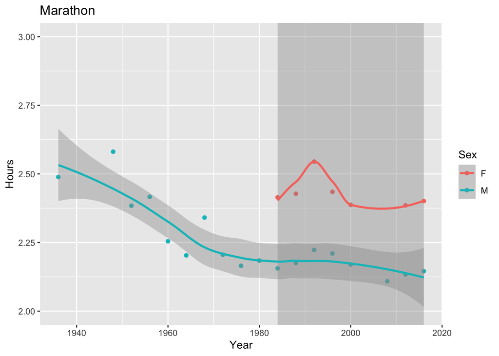

```r
Olympic_perf_plot <- ggplot(data = marathon, aes(Year, Hours, colour=Sex)) +
  coord_cartesian(ylim=c(2,3)) +
  geom_point() +
  ggtitle("Marathon") +
  geom_smooth()
Olympic_perf_plot
```

Women began running the 800 m race in 1960. Initially, their rate of improvement was so much greater than the men’s, it appeared that eventually women would cathch the men. Utlimately, this was not the case as the performance of both sexes plateaued beginning in the 1980s.

```r
m800 <- Olympics_Athletics %>%
  filter(Event == "800 metres")
  m800$Sec = as.numeric(m800$Time)/60
m800
```

```
## # A tibble: 30 × 7
##    Sport     Event       Year Sex   Time  Rank    Sec
##    <chr>     <chr>      <dbl> <chr> <chr> <chr> <dbl>
##  1 Athletics 800 metres  2016 M     6135  1      102.
##  2 Athletics 800 metres  2012 M     6091  1      102.
##  3 Athletics 800 metres  2008 M     6305  1      105.
##  4 Athletics 800 metres  2000 M     6308  1      105.
##  5 Athletics 800 metres  1996 M     6178  1      103.
##  6 Athletics 800 metres  1992 M     6246  1      104.
##  7 Athletics 800 metres  1988 M     6225  1      104.
##  8 Athletics 800 metres  1984 M     6180  1      103
##  9 Athletics 800 metres  1980 M     6340  1      106.
## 10 Athletics 800 metres  1976 M     6230  1      104.
## # … with 20 more rows
```

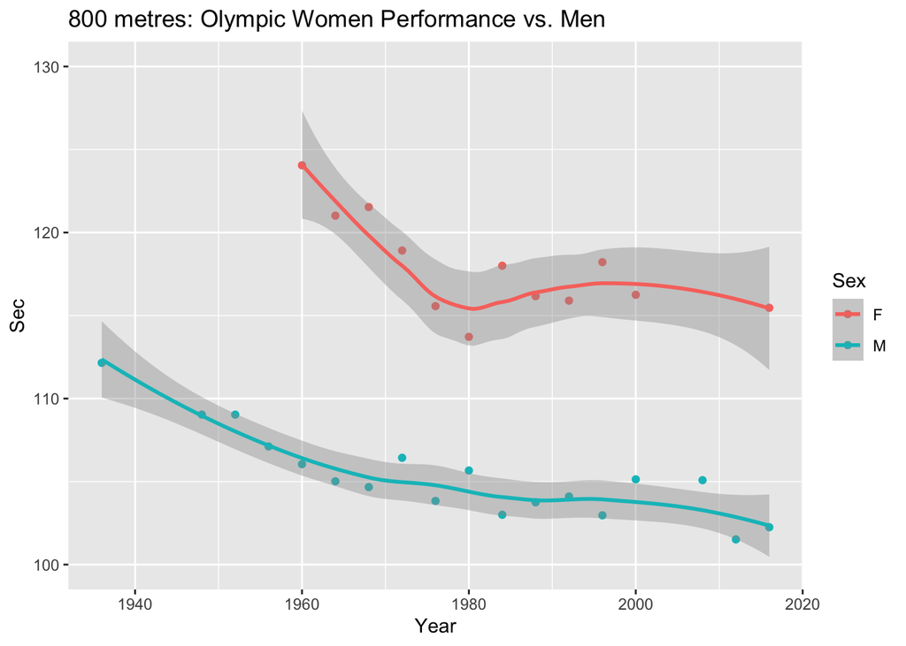

```r
Olympic_perf_plot <- ggplot(data = m800, aes(Year, Sec, colour=Sex)) +
  coord_cartesian(ylim=c(100,130)) +
  geom_point() +
  ggtitle("800 metres: Olympic Women Performance vs. Men") +
  geom_smooth()
Olympic_perf_plot
```

Women’s and men’s performance in the 100 m dash has been steadily improving since records were obtained in 1936. Of note is the outlier, Florence “Flo Jo” Griffith, who continues to hold the world record of 10.49 seconds set in 1988.

```r
m100 <- Olympics_Athletics %>%
  filter(Event == "100 metres")
  m100$Sec = as.numeric(m100$Time)
  m100
```

```
## # A tibble: 35 × 7
##    Sport     Event       Year Sex   Time  Rank    Sec
##    <chr>     <chr>      <dbl> <chr> <chr> <chr> <dbl>
##  1 Athletics 100 metres  2016 M     9.81  1      9.81
##  2 Athletics 100 metres  2012 M     9.63  1      9.63
##  3 Athletics 100 metres  2008 M     9.69  1      9.69
##  4 Athletics 100 metres  2004 M     9.85  1      9.85
##  5 Athletics 100 metres  2000 M     9.87  1      9.87
##  6 Athletics 100 metres  1996 M     9.84  1      9.84
##  7 Athletics 100 metres  1992 M     9.96  1      9.96
##  8 Athletics 100 metres  1988 M     9.92  1      9.92
##  9 Athletics 100 metres  1984 M     9.99  1      9.99
## 10 Athletics 100 metres  1980 M     10.25 1     10.2
## # … with 25 more rows
```

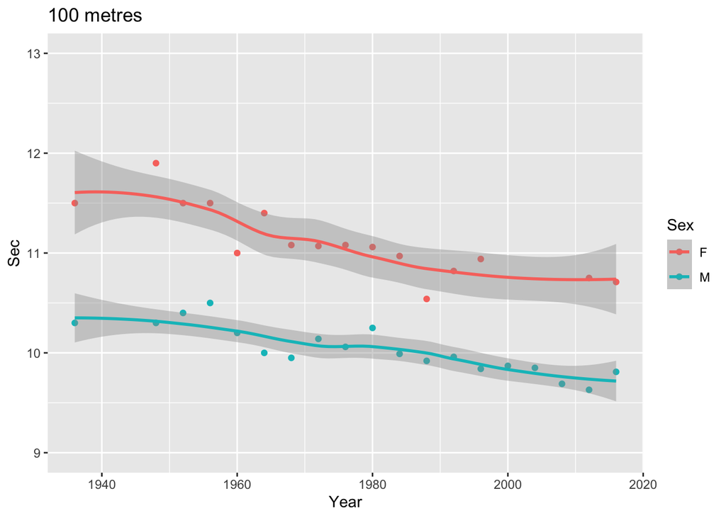

```r
Olympic_perf_plot <- ggplot(data = m100, aes(Year, Sec, colour=Sex)) +
  coord_cartesian(ylim=c(9,13)) +
  geom_point() +
  ggtitle("100 metres") +
  geom_smooth()
Olympic_perf_plot
```